# Zaman Serileri Analizi

## 3.5 İndeks Ayarlaması

- Örnek olması açısından World Bank’ten “Türkiye için Tüketici Fiyatları İndeksi (2010 Baz Yılı)” verisini indirip yükleyelim.
- Daha sonra indirip yüklediğimiz bu veriyi temizleyelim ve düzenleyelim.
- Daha sonra temizlenmiş ve düzenlenmiş veri üzerinden yeni bir baz yılı belirleyip bu baz yila göre **indeks ayarlaması** yapalım.
- Son olarak yeni baz yılı ile hesaplanmış veriyi grafiğe dökelim.

```r
WDIsearch(string = "consumer.*price.*index", field = "name", short = TRUE, cache = NULL) ## Olası seriler ve kodları. Biz "FP.CPI.TOTL" Consumer price index (2010 = 100) datasını kullanacağız. 2010 baz yılı kullanılıyor.
```

|  | indicator | name |
| --- | --- | --- |
| 7176 | EP.CPI.1996 | Consumer Price Index in 42 cities base 1996 |
| 7177 | EP.CPI.2002 | Consumer Price Index in 45 cities base 2002 |
| 7178 | EP.CPI.2007 | Consumer Price Index in 66 cities base 2007 |
| 7179 | EP.CPI.2012 | Consumer Price Index in 82 cities base 2012 |
| 7180 | EP.CPI.2018 | Consumer Price Index in 90 cities base 2018 |
| 8923 | FP.CPI.TOTL | Consumer price index (2010 = 100) |

```r
data <- WDI(country = c("TR"), indicator = "FP.CPI.TOTL", start = 1960, end = 2026, extra = FALSE)  ## Bir önceki kodda belirlediğimiz indikatör ismini ve ülke kısaltmasını kullanıyoruz. Datanın başlangıç ve bitiş tarihlerini de ayrı ayrı belirtiyoruz.
data ## Datanın yapısını inceleyelim.
```

| country | iso2c | iso3c | year | FP.CPI.TOTL |
| --- | --- | --- | --- | --- |
| Turkiye | TR | TUR | 2024 | 1322.883968609870 |
| Turkiye | TR | TUR | 2023 | 834.593142750374 |
| Turkiye | TR | TUR | 2022 | 542.438807922272 |
| Turkiye | TR | TUR | 2021 | 314.806147234679 |
| Turkiye | TR | TUR | 2020 | 263.223561285501 |
| Turkiye | TR | TUR | 2019 | 234.437126307922 |
| Turkiye | TR | TUR | 2018 | 203.545403587444 |
| Turkiye | TR | TUR | 2017 | 174.968703288490 |
| Turkiye | TR | TUR | 2016 | 157.424794469357 |
| Turkiye | TR | TUR | 2015 | 146.067825112108 |

[output cut: 55 more lines]

```r
data <- data[, c("year", "FP.CPI.TOTL")] ## İstediğimiz değişkenleri belirtiyoruz.
colnames(data) <- c("Year", "CPI.2010") ## Değişkenlere yeni isimler veriyoruz.
data$Date <- as.Date(paste(data$Year, "1", "1", sep = "-")) ## Date adlı yeni bir değişken oluşturuyoruz.
data <- data[, c("Date", "Year", "CPI.2010")] ## Değişkenleri sütun olarak sıralıyoruz.
data <- data[order(data$Date, data$Year, decreasing = FALSE, na.last = FALSE), ] ## Datayı tarihe göre sıralıyoruz.
rownames(data) <- 1:nrow(data) ## Satır sayılarını sıralıyoruz.
data ## Datanın yapısını inceleyelim.
```

|  | Date | Year | CPI.2010 |
| --- | --- | --- | --- |
| 1 | 1960-01-01 | 1960 | 0.000053952385 |
| 2 | 1961-01-01 | 1961 | 0.000055664217 |
| 3 | 1962-01-01 | 1962 | 0.000057828620 |
| 4 | 1963-01-01 | 1963 | 0.000061508086 |
| 5 | 1964-01-01 | 1964 | 0.000062196754 |
| 6 | 1965-01-01 | 1965 | 0.000065030148 |
| 7 | 1966-01-01 | 1966 | 0.000070539499 |
| 8 | 1967-01-01 | 1967 | 0.000080397319 |
| 9 | 1968-01-01 | 1968 | 0.000085258333 |
| 10 | 1969-01-01 | 1969 | 0.000089456619 |

[output cut: 55 more lines]

```r
# Yeni bir baz yılına göre (2019 Baz Yılı) indeksi tekrar hesaplıyoruz.
data$CPI.2019 <- (data$CPI.2010/data[data$Year == 2019, "CPI.2010"]) * 100
data ## Datanın yapısını inceleyelim.
```

|  | Date | Year | CPI.2010 | CPI.2019 |
| --- | --- | --- | --- | --- |
| 1 | 1960-01-01 | 1960 | 0.000053952385 | 0.000023013584 |
| 2 | 1961-01-01 | 1961 | 0.000055664217 | 0.000023743772 |
| 3 | 1962-01-01 | 1962 | 0.000057828620 | 0.000024667006 |
| 4 | 1963-01-01 | 1963 | 0.000061508086 | 0.000026236495 |
| 5 | 1964-01-01 | 1964 | 0.000062196754 | 0.000026530249 |
| 6 | 1965-01-01 | 1965 | 0.000065030148 | 0.000027738844 |
| 7 | 1966-01-01 | 1966 | 0.000070539499 | 0.000030088877 |
| 8 | 1967-01-01 | 1967 | 0.000080397319 | 0.000034293766 |
| 9 | 1968-01-01 | 1968 | 0.000085258333 | 0.000036367249 |
| 10 | 1969-01-01 | 1969 | 0.000089456619 | 0.000038158043 |

[output cut: 55 more lines]

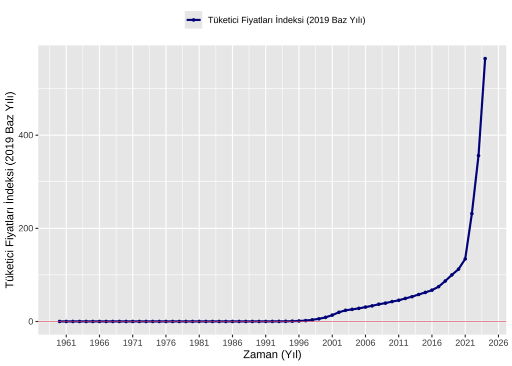

```r
# Grafik
temp <- data
variable <- "CPI.2019"
variable.name <- "Tüketici Fiyatları İndeksi (2019 Baz Yılı)"

ggplot(temp) +
    geom_line(aes(x = Date, y = temp[ , variable], colour = "Variable"), linetype = 1, size = 1) +
    geom_point(aes(x = Date, y = temp[ , variable], colour = "Variable"), size = 1) +
    xlab("Zaman (Yıl)") + ylab(variable.name) +
    # labs(title = "Başlık") + ## Grafik için isterseniz başlık eklenebilir.
    scale_x_date(date_breaks = "5 year", date_labels = "%Y") +
    geom_hline(aes(yintercept = 0), show.legend = FALSE, linetype = 1, colour = 2, size = 0.25) +
    scale_colour_manual(name = "", labels = c(variable.name), values = c("Variable" = "darkblue")) +
    theme_grey() +
    theme(legend.position = "top")
```

## 3.6 Matematiksel Transformasyon

- Örnek olması açısından Yahoo Finance’ten “Döviz Kuru (TL/USD)” verisini indirip yükleyelim.
- Daha sonra indirip yüklediğimiz bu veriyi temizleyelim ve düzenleyelim.
- Daha sonra temizlenmiş ve düzenlenmiş veri üzerinde **logaritmik transformasyon** ve **Box-Cox transformasyonu** uygulayalım.
- Son olarak düzey formundaki, logaritmik formdaki ve Box-Cox transformasyonu ile değiştirilmiş veriyi grafiğe dökelim.

```r
loadSymbols(Symbols = "TRY=X", periodicity = "daily", return.class = "data.frame") ## Datanın indirilmesi.
data <- data.frame(Date = gsub("\\.", "-", gsub("X", "", rownames(`TRY=X`))), Close = `TRY=X`$`TRY=X.Close`, stringsAsFactors = FALSE) ## Datanın data.frame olarak kaydedilmesi.
data$Date <- as.Date(data$Date) ## Date kategori olarak değiştirildi.
data <- data[order(data$Date, decreasing = FALSE, na.last = FALSE), ] ## Datayı tarihe göre sıralıyoruz.
rownames(data) <- 1:nrow(data) ## Satır sayılarını sıralıyoruz.
data ## Datanın yapısını inceleyelim.
```

|  | Date | Close |
| --- | --- | --- |
| 1 | 2007-01-01 | 1.4080000 |
| 2 | 2007-01-02 | 1.4012001 |
| 3 | 2007-01-03 | 1.4020000 |
| 4 | 2007-01-04 | 1.4119999 |
| 5 | 2007-01-05 | 1.4360000 |
| 6 | 2007-01-08 | 1.4360000 |
| 7 | 2007-01-09 | 1.4410000 |
| 8 | 2007-01-10 | 1.4400001 |
| 9 | 2007-01-11 | 1.4290000 |
| 10 | 2007-01-12 | 1.4220001 |

[output cut: 990 more lines]

```r
# Logaritmik transformasyon.
data$Ln.Close <- log(data$Close)

# Box-Cox transformasyonu.
value <- data$Close
## Box-cox transformasyonu ile bulunan lambda değerine göre ham veri değiştiriliyor: Eğer lambda = 1 ise transformasyona gerek yok, eğer lambda == 0 ise ln(x), ve eğer lambda farklı bir değer ise (x^lambda - 1)/lambda.
s.lambda <- forecast::BoxCox.lambda(value, method = c("loglik"), lower = -2, upper = 2) ## Box-cox transformasyonu sonucunda bulunan lambda değeri. method = c("guerrero") kriteri de kullanılabilir. Genelde kullanılan alt limit -2 ve üst limit ise 2'dir.
if(s.lambda == 1) { ## Lambda = 1.
    value.boxcox <- value
    message("Box-Cox transformasyonu sonucu: Transformasyona gerek yok.")
} else if(s.lambda == 0) { ## Lambda = 0.
    value.boxcox <- log(value)
    message("Box-Cox transformasyonu sonucu: Logaritmik Transformasyon yapıldı.")
} else { ## Lambda farklı bir değer ise.
    value.boxcox <- (value^s.lambda - 1)/s.lambda
    message(paste0("Box-Cox transformasyonu sonucu: λ = ", round(s.lambda, 2), " kullanılarak Box-Cox transformasyonu yapıldı."))
}
```

```
#> Box-Cox transformasyonu sonucu: λ = -0.45 kullanılarak Box-Cox transformasyonu yapıldı.
```

```r
data$Box.Cox.Close <- value.boxcox
data ## Datanın yapısını inceleyelim.
```

|  | Date | Close | Ln.Close | Box.Cox.Close |
| --- | --- | --- | --- | --- |
| 1 | 2007-01-01 | 1.4080000 | 0.34217025 | 0.31712873 |
| 2 | 2007-01-02 | 1.4012001 | 0.33732905 | 0.31297389 |
| 3 | 2007-01-03 | 1.4020000 | 0.33789975 | 0.31346415 |
| 4 | 2007-01-04 | 1.4119999 | 0.34500710 | 0.31955919 |
| 5 | 2007-01-05 | 1.4360000 | 0.36186146 | 0.33393528 |
| 6 | 2007-01-08 | 1.4360000 | 0.36186146 | 0.33393528 |
| 7 | 2007-01-09 | 1.4410000 | 0.36533731 | 0.33688650 |
| 8 | 2007-01-10 | 1.4400001 | 0.36464315 | 0.33629749 |
| 9 | 2007-01-11 | 1.4290000 | 0.35697491 | 0.32977847 |
| 10 | 2007-01-12 | 1.4220001 | 0.35206437 | 0.32559203 |

[output cut: 990 more lines]

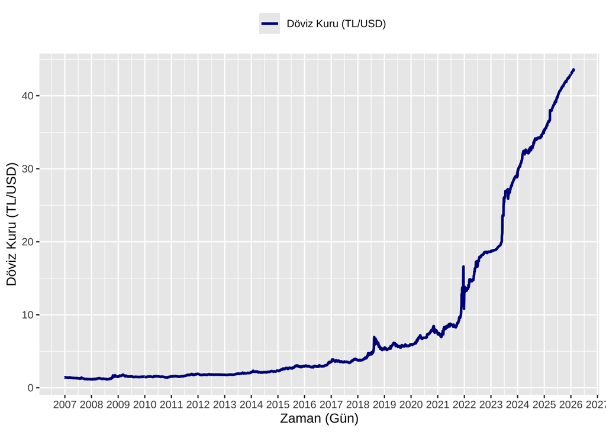

```r
# Düzey Formu: Grafik
temp <- data
variable <- "Close"
variable.name <- "Döviz Kuru (TL/USD)"

ggplot(temp) +
    geom_line(aes(x = Date, y = temp[ , variable], colour = "Variable"), linetype = 1, size = 1) +
    xlab("Zaman (Gün)") + ylab(variable.name) +
    # labs(title = "Başlık") + ## Grafik için isterseniz başlık eklenebilir.
    scale_x_date(date_breaks = "1 year", date_labels = "%Y") +
    scale_colour_manual(name = "", labels = c(variable.name), values = c("Variable" = "darkblue")) +
    theme_grey() +
    theme(legend.position = "top")
```

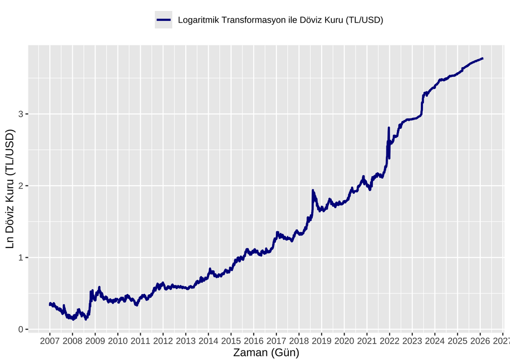

```r
# Logaritmik Form: Grafik
temp <- data
variable <- "Ln.Close"
y.lab <- "Ln Döviz Kuru (TL/USD)"
variable.name <- "Logaritmik Transformasyon ile Döviz Kuru (TL/USD)"

ggplot(temp) +
    geom_line(aes(x = Date, y = temp[ , variable], colour = "Variable"), linetype = 1, size = 1) +
    xlab("Zaman (Gün)") + ylab(y.lab) +
    # labs(title = "Başlık") + ## Grafik için isterseniz başlık eklenebilir.
    scale_x_date(date_breaks = "1 year", date_labels = "%Y") +
    scale_colour_manual(name = "", labels = c(variable.name), values = c("Variable" = "darkblue")) +
    theme_grey() +
    theme(legend.position = "top")
```

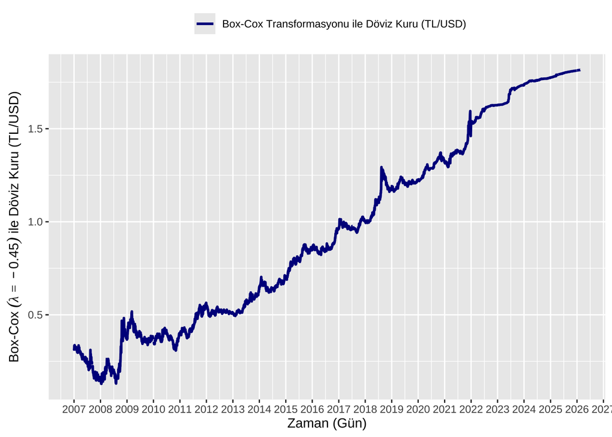

```r
# Box-Cox Transformasyonu: Grafik
temp <- data
variable <- "Box.Cox.Close"
y.lab <- paste0("Box-Cox $(\\lambda = ", round(s.lambda, 2), ")$ ile Döviz Kuru (TL/USD)")
variable.name <- paste0("Box-Cox Transformasyonu ile Döviz Kuru (TL/USD)")

ggplot(temp) +
    geom_line(aes(x = Date, y = temp[ , variable], colour = "Variable"), linetype = 1, size = 1) +
    xlab("Zaman (Gün)") + ylab(latex2exp::TeX(y.lab)) +
    # labs(title = "Başlık") + ## Grafik için isterseniz başlık eklenebilir.
    scale_x_date(date_breaks = "1 year", date_labels = "%Y") +
    scale_colour_manual(name = "", labels = c(variable.name), values = c("Variable" = "darkblue")) +
    theme_grey() +
    theme(legend.position = "top")
```